# Analyse du sentiment - Airbnb

CB

9 avril 2019

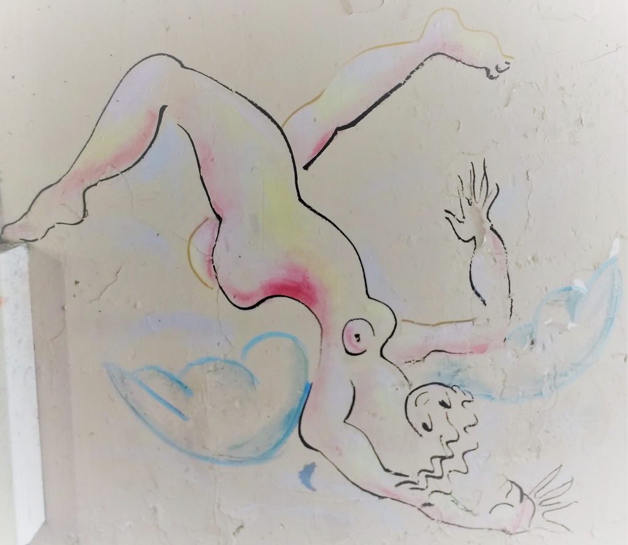

rues de paris

# 1. Introduction

Dans cette étude on s’appuie sur un outil de mesure du sentiment, le NRC de Mohammad and Turney (2013), qui présente l’avantage d’offrir différents indicateurs de sentiment, des polarités, et une palette d’émotions qui s’appuient sur les travaux de Plutchik (1982) .

dans cette note technique, on explore la sensibilité et la cohérence de cet indicateur et on y découvre la très forte positivité du contenu généré par #airbnb.

## 1.1 Initialisation des packages

On trouvera le rmd dans le [projet github](https://github.com/BenaventC/AirbnbStudies) . Cette note ne publie que les résultats et le commentaires sont lapidaires.

## 1.2 Extraction et recodage des données

voir le rmd dans le [projet github](https://github.com/BenaventC/AirbnbStudies)

```
## # A tibble: 5 x 6
##   listing_id      id date       reviewer_id reviewer_name comments
##        <dbl>   <dbl> <date>           <dbl> <chr>         <chr>
## 1       2577  3.66e8 2019-01-02    28047930 Kate          "Beautiful apart~
## 2       5396  4.82e3 2009-06-30       19995 Sarah         Perfect location~
## 3       5396  4.97e3 2009-07-03       20117 Chris         This is a nice p~
## 4       5396  5.24e3 2009-07-08       22190 Annelaure     Nice studio, ver~
## 5       5396  9.62e3 2009-09-10       11947 Jean          "Superb location~
```

## 1.3 Sélection du sous corpus en anglais

avec `textcat` pour l’identification des langues. On choisit l’anglais qui représente les deux tiers des commentaires comme on en a fait l’étude [ici](https://benaventc.github.io/AirbnbStudies/Avis.html)

```r
#on échantillonne pour tester le code
df<-reviews %>% sample_n(10000)
#un format qu'aime lubridate
df$date<-as.POSIXct(df$date)
#on identifie la langue
df$langue<-textcat(df$comments) #attention c'est long - une bonne dizaines de minutes.
#on selectionne l'anglais
df_en <-subset(df,langue=="english")
```

# 2. Analyse du sentiment

On utilise le package [syuzhet](https://www.rdocumentation.org/packages/syuzhet/versions/1.0.4) et en particulier le dictionnaire “nrc” developpé par Mohammad, Saif M. et al .

```r
df_en$nbcar<-as.numeric(nchar(df_en$comments))
df_en<-df_en %>% filter(nbcar>10 & nbcar<1200)
#paramètres
method <- "nrc"
lang <- "english"
phrase<-as.character(df_en$comments)
#extraction
my_text_values_french<- get_sentiment(phrase, method=method, language=lang)
```

## 2.1 La distribution du sentiment

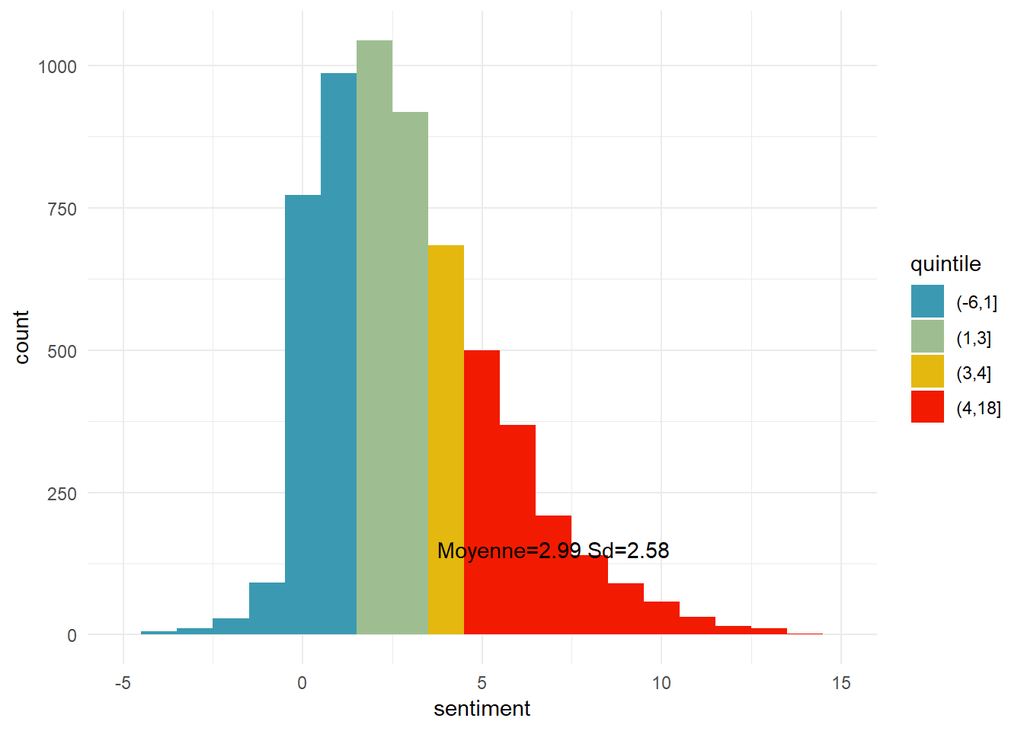

## 2.2 Identification du genre

Un commentaire c’est une date, un prénom et un contenu. A partir du prénom on peut déduire le genre en employant des tables de correspondance. Pour les prénoms en anglais , la liste suivante semble intéressante, d’autant plus que d’origine indienne, elle inclue bien d’autres qui s’expriment aussi dans cette langue [gender by names](https://data.world/arunbabu).

*nota*: on choisit la palette Grand Budapest 1, pour éviter les stéréotype de genre dans le style puéril du rose et bleu (on est preneur de solution plus élégantes). Quatre genres de prénoms sont distingués : masculin et féminin, convenant aux deux genres, et ceux non identifiés.

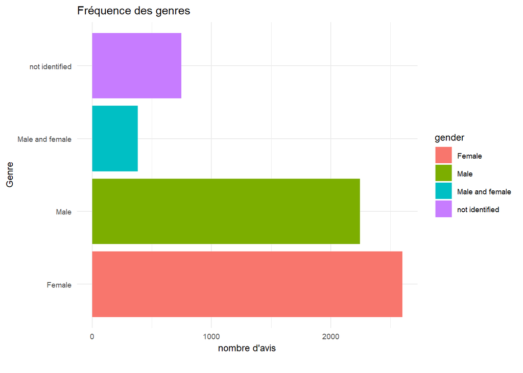

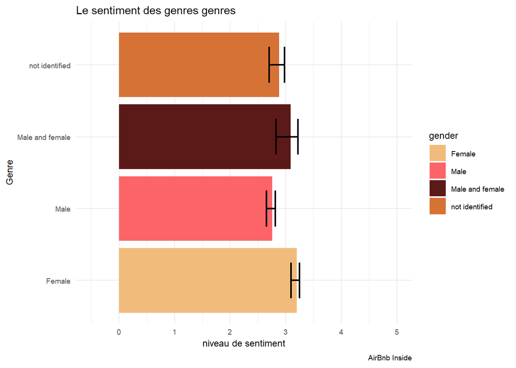

Analyse de variance

| term | sumsq | meansq | df | statistic | p.value | etasq | partial.etasq | omegasq | partial.omegasq | cohens.f | power |
| --- | --- | --- | --- | --- | --- | --- | --- | --- | --- | --- | --- |
| (Intercept) | 26600.97 | 26600.97 | 1 | 4023.8 | 0 | 0.4 | 0.40 | 0.4 | 0.40 | 0.82 | 1 |
| gender | 245.96 | 81.99 | 3 | 12.4 | 0 | 0.0 | 0.01 | 0.0 | 0.01 | 0.08 | 1 |
| Residuals | 39486.92 | 6.61 | 5973 | NA | NA | NA | NA | NA | NA | NA | NA |

## 2.3 Un indicateur dépendant de la longueur du texte

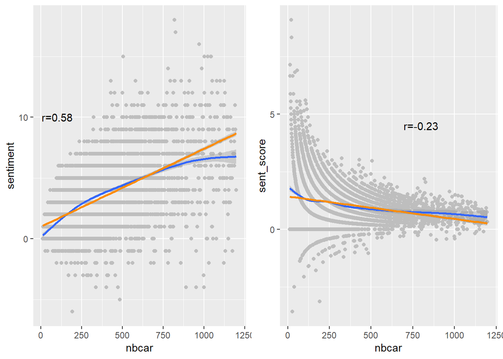

avec cet indicateur de sentiment pondéré par la taille du commentaire, les femmes sont moins positive que les hommes

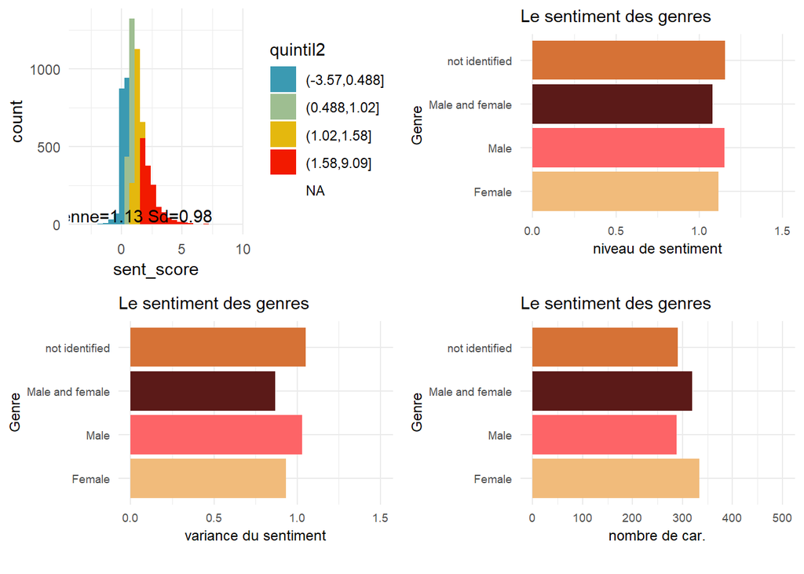

# 3. Analyse des émotions - nrc

Le même outil fournit un autre système d’annotation qui compte les mentions d’éléments positifs ou négatifs, ainsi que d’émotions définies sur la base de l’inventaire de Plutchik (1982) on utilise simplement la fonction `get_nrc_sentiment`, en précisant le dictionnaire adéquat. L’échelle comprend en fait deux éléments : les 8 émotion de base *au sens de pluchik, et deux indicateurs de polarité.

L’opérationnalisation réalisée par Mohammad and Turney (2013) s’inscrit dans une tradition de la recherche en marketing, se souvenir de Havlena and Holbrook (1986) et de Westbrook and Oliver (1991)

## 3.1 Les polarités

On s’intéresse d’abord aux mentions positives et négatives. (la mesure permet ainsi une dyssémétrie des deux polarités, il y a le bien, le mal, le mal et le bien, mais aussi si qui n’est ni mal ni bien).

Les textes étant inégaux en taille on va ramener l’indicateur de polarité au nombre de caractères (sur une base de 100 c) de chaque contribution. En effet l’algo compte les valence et leur intensité est proportionnel à la longueur du texte. Ce qui est clairement démontré par la seconde figue.

A partir de ces deux mesures, 4 indicateurs peuvent être construits

- Positivité : nombre de termes positifs pour 100 signes.
- Négativitivé : nombre de termes négatifs pour 100 signes.
- Valence : rapport du nombre de termes positifs sur les négatifs.
- Expressivité : nombre de termes positifs et négatifs pour 100 signes.

le dernier graphe nous apprend que les jugements plutôt positifs sont aussi les plus expressifs. La “froideur” des commentaires les plus négatifs reflète-t-elle une crainte de la désaprobation sociale? C’est une piste de recherche à poursuivre, on pourrait s’attendre à ce que les commentaires les plus négatifs surgissent plus facilement si la densité des négatives est plus importante et observer une sorte d’autorrélation.

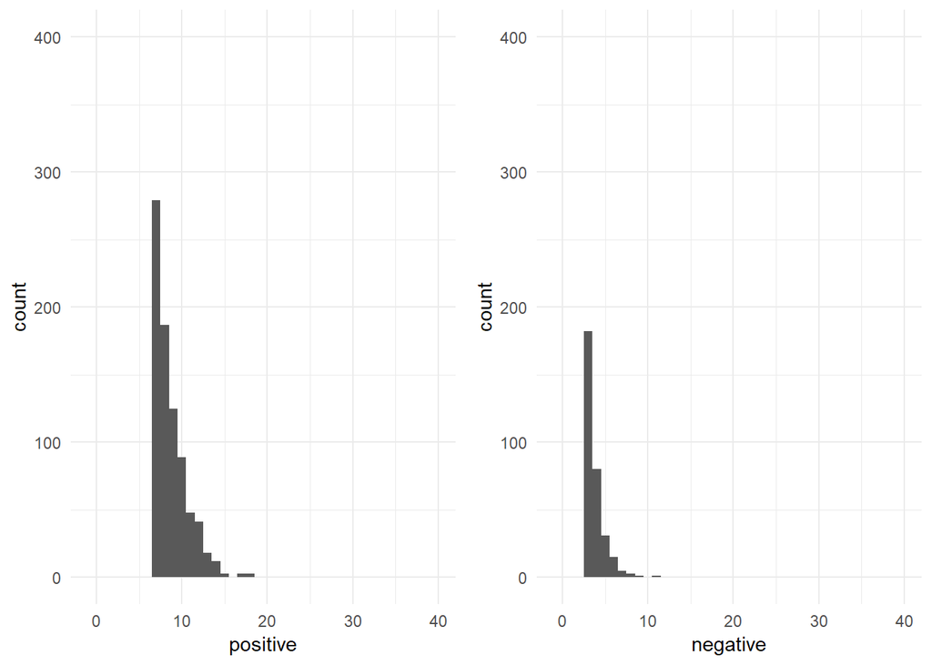

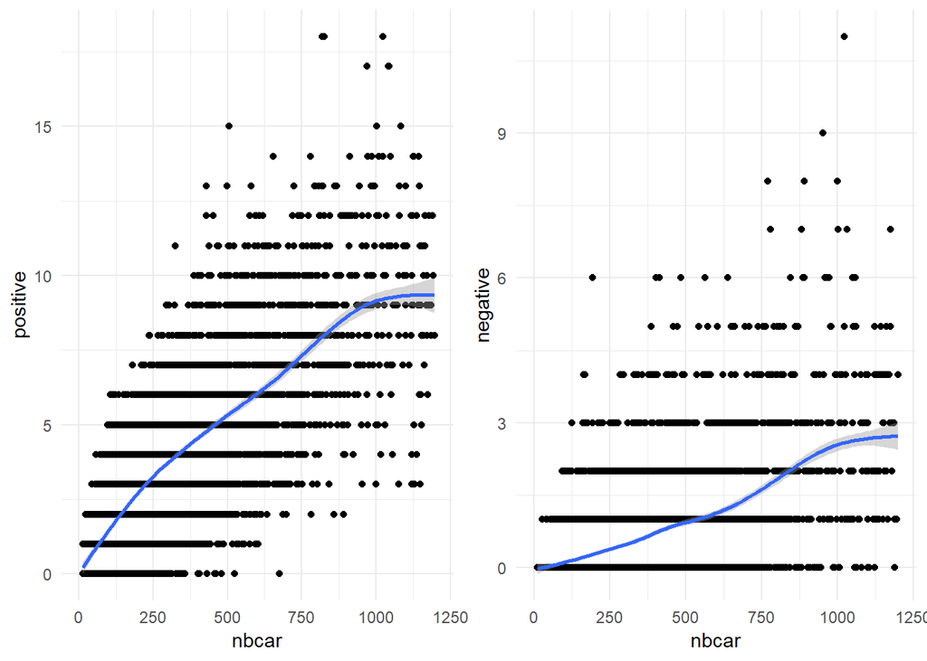

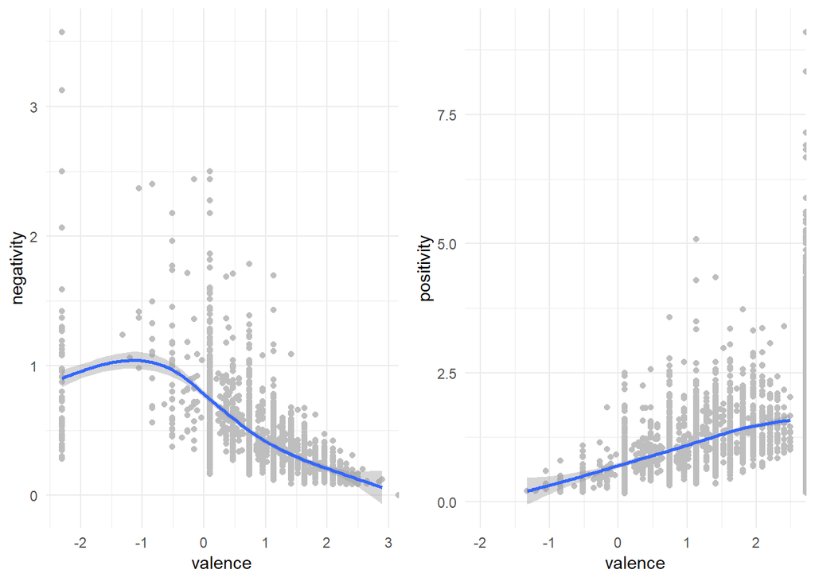

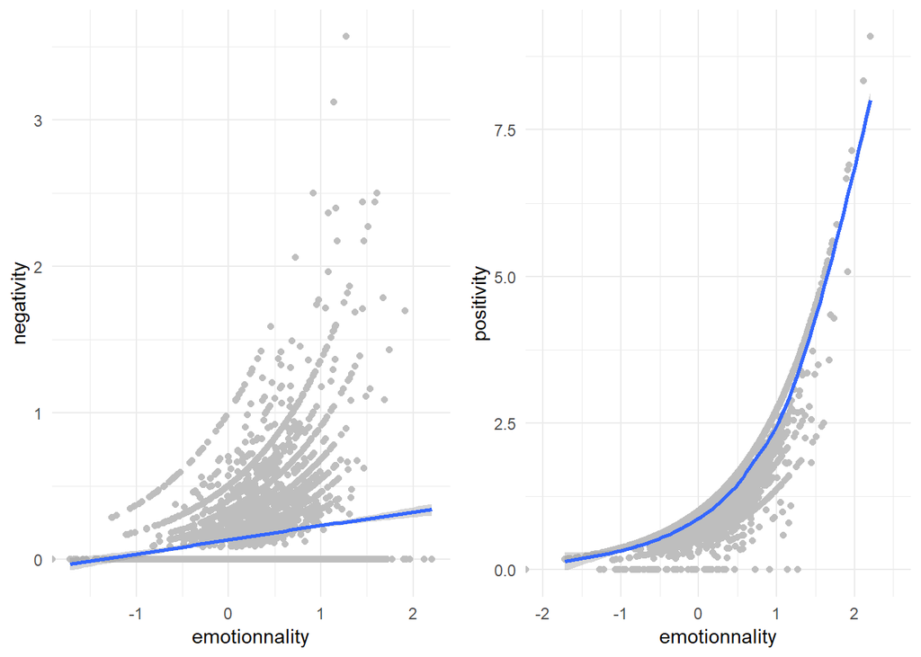

## 3.2 Les émotions

On se concentre sur les 8 facettes de l’émotion telle que conceptualisée par [Plutchik](https://positivepsychologyprogram.com/emotion-wheel/)

dont on reprend les definition en anglais :

" * trust goes from acceptance to admiration * fear goes from timidity to terror * surprise goes from uncertainty to amazement * sadness goes from gloominess to grief * disgust goes from dislike to loathing * anger goes from annoyance to fury * anticipation goes from interest to vigilance * joy goes from serenity to ecstasy"

et mesurée sur la base des textes par l’outil NCR élaborée par [Mohammad Saif](http://saifmohammad.com/WebPages/lexicons.html) et pour le français [voir](http://sentiment.nrc.ca/lexicons-for-research/).

On peut raisonner en part relative des émotions dans le mesure où l’outil NCR compte les éléments probables de chacune des émotions. C’est pourquoi on recode les variables, encore une fois les textes long risquent de peser plus que les textes courts, la normalisation est nécessaire.

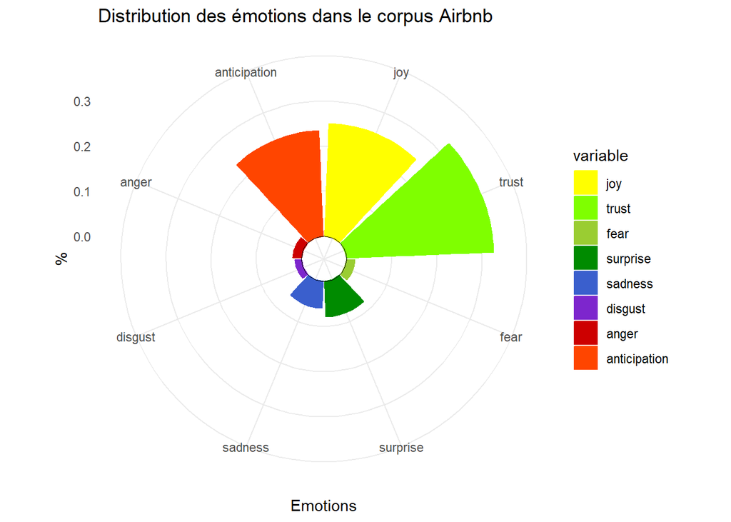

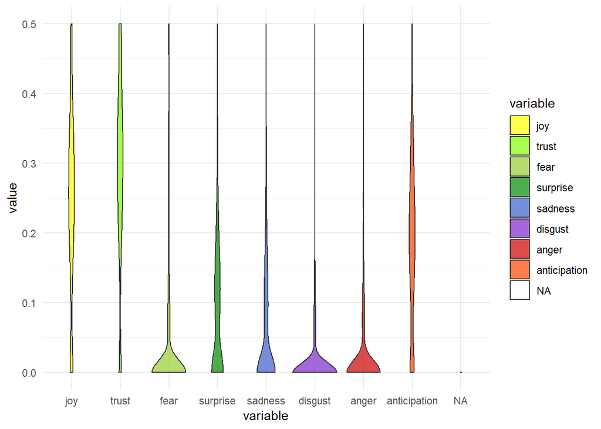

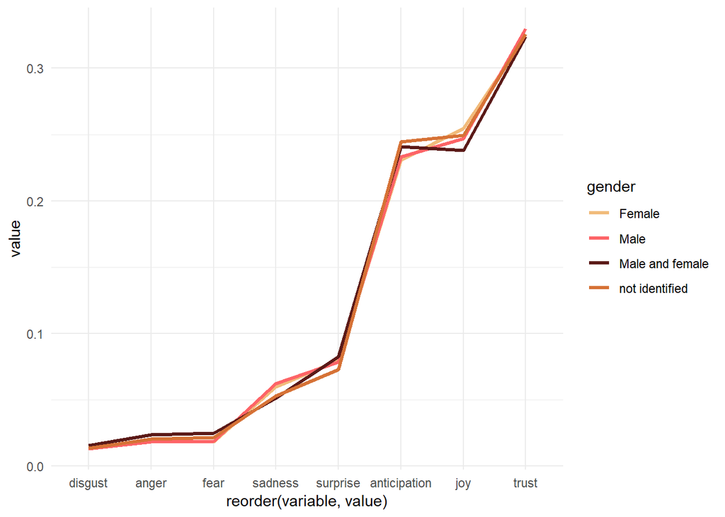

## 3.4 les évolutions

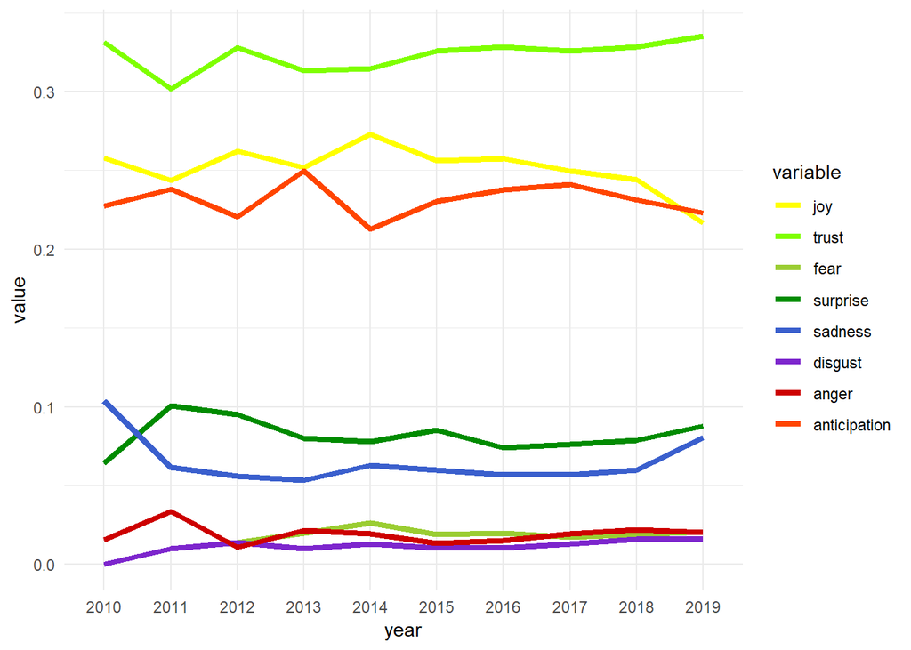

# 4. Conclusion

## 4.1 Le résultat

Un sentiment très positif qui pose d’emblée la question du biais en faveur des commentaires positifs? quelle importance, quelle source?

Une activité peu genrée

une stabilisation dès 2013

## 4.2 limites

L’analyse du sentiment est un processus plein de piège, et dépends des dictionnaires, celà pose un problème de qualité de la méthode. Il faudra sans doute des benchmark, au minimum l’établissement d’un standard, et examiner la convergence de différentes méthodes.

Mais ce n’est pas un problème pour l’analyse comparative si les biais sont systématiques et proportionnels. A défaut d’une mesure aux grandeurs établie, on dispose d’un instrument ordinal qui permet au point les comparaisons. Quant à la sensibilité et la fiabilité, une étape suivante sera d’étudier leur convergence avec d’autres méthodes.

## 4.3 les extensions

# 5. Références

Havlena, William J., and Morris B. Holbrook. 1986. “The Varieties of Consumption Experience: Comparing Two Typologies of Emotion in Consumer Behavior.” *Journal of Consumer Research* 13 (3): 394. https://doi.org/10.1086/209078.

Mohammad, Saif M., and Peter D. Turney. 2013. “Crowdsourcing a Word-Emotion Association Lexicon.” *Computational Intelligence* 29 (3): 436–65.

Plutchik, Robert. 1982. “A Psychoevolutionary Theory of Emotions.” *Social Science Information* 21 (4-5): 529–53. https://doi.org/10.1177/053901882021004003.

Westbrook, Robert A., and Richard L. Oliver. 1991. “The Dimensionality of Consumption Emotion Patterns and Consumer Satisfaction.” *Journal of Consumer Research* 18 (1): 84. https://doi.org/10.1086/209243.